# Modeling

```r
library(GradientMetrics)
# library(dplyr)
library(tidyverse)
library(MASS)
library(ordinal)
```

```r
# library(glmmLasso)
library(highcharter)
library(nnet)
library(cvms)
library(ggeffects)
```

## Data Processing

The goal of the modeling process is to answer the question: how each attribute (and its level) affects the likelihood of downloading of the app. In other words, I need to build statistical models that model the effects of each independent variables (a.k.a. each attribute) on the response variable (paricipant’s lieklihood of download, on a rating-based scale).

```r
data("survey_data")
data("experiment_data")
table(exp_data$answer)
```

```
#>
#>    1    2    3    4
#> 4625 2316 2199 1564
```

```r
model_data = exp_data %>%
  mutate(
    response_id = as.factor(response_id),
    answer = ordered(answer, levels = c("1", "2", "3","4")),
    offer = as.factor(offer),
    outcome = as.factor(outcome),
    rtb= as.factor(rtb),
    social_proof = as.factor(social_proof),
    duration = factor(duration,levels = c("3 months","6 months","12 months")),
    price = factor(price,levels = c("$20/month","$30/month","$40/month"))
  ) %>%
  dplyr::select(-c(task)) #response_id

# merge categories in response variable
# model_data2 = model_data %>%
#   mutate(answer = case_when(
#     answer == 1 ~ 1,
#     answer %in% c(2,3) ~ 2,
#     answer == 4 ~ 3
#   ),
#   answer =  ordered(answer, levels = c("1", "2", "3")),
#   duration = factor(duration,levels = c("3 months","6 months","12 months")),
#   price = factor(price,levels = c("$20/month","$30/month","$40/month"))
#   )
#
# table(model_data2$answer)
# # 3 levels
IDs = unique(model_data$response_id)
set.seed(123)
train_model_data = model_data %>%
  filter(response_id %in% sample(IDs,round(0.8*length(IDs),0)))
test_model_data = model_data %>%
  filter(!(response_id %in% sample(IDs,round(0.8*length(IDs),0))))
# str(model_data2$duration)
```

## Multinomial Regression

Multinomial logistic regression is used to model nominal outcome variables, in which the log odds of the outcomes are modeled as a linear combination of the predictor variables. It’s a extension of binary logistic regression that allows for more than two categories for the dependent variable. Similar to binary logistic regression, it uses maximum likelihood estimation to evaluate the probability of belonging to a specific category.

However, multinomial regression does not address the ordinal structure of the response variable in the data. Therefore, it can serve as a baseline model to compare the performance with ordinal logistic regression model (presented in the next section).

Mathematically, with p number of independent variables and response variable Y with categories j = 1,…,J, the algorithm selects 1 response category as base level and form odds of remaining J-1 categories against this level:

$$log(\frac{\pi_{ij}}{\pi_{iJ}}) = \alpha_{j}+x_i'\beta_{j}\\
where \\
\pi_{ij} = P(Y_i = j) \\
\alpha_j = \text{intercept} \\
\beta_j \text{ is a vector of regression coefficients for j=1,2,...,J−1}$$

```
#> Call:
#> multinom(formula = answer ~ duration + offer + outcome + price +
#>     rtb + social_proof, data = train_model_data, Hess = TRUE)
#>
#> Coefficients:
#>   (Intercept) duration6 months duration12 months
#> 2  -0.6194388       0.08989716        -0.0351134
#> 3  -0.3434939      -0.03517800        -0.1014070
#> 4  -0.7391196       0.07574323         0.1351307
#>   offerhelp you lead a better life offerhelp you sleep without more pills
#> 2                      0.093233230                             0.12408063
#> 3                      0.118345305                             0.11139258
#> 4                      0.009955127                             0.01433275
#>   offerimprove your health for the long-run offerimprove your sleep sustainably
#> 2                                0.14467419                          0.03300554
#> 3                                0.08398876                          0.07384018
#> 4                                0.04851494                          0.01215837
#>   outcomechanging your sleep mindset
#> 2                       -0.001923929
#> 3                        0.052671883
#> 4                       -0.042700030
#>   outcomeempowering you to take back your sleep habits price$30/month
#> 2                                          -0.11939894     -0.1218502
#> 3                                          -0.08194174     -0.3862105
#> 4                                          -0.17615101     -0.5695811
#>   price$40/month rtbcognitive behavioral therapy
#> 2     -0.2389815                      0.02627075
#> 3     -0.7198888                      0.02900574
#> 4     -0.6389399                     -0.03353886
#>   rtbdaily text messages from a coach rtbpersonalized, human coaching
#> 2                          -0.1053026                     0.074399557
#> 3                          -0.1977104                    -0.042961700
#> 4                          -0.2071930                    -0.005786284
#>   rtbthe support of a community of people just like you
#> 2                                            0.05541335
#> 3                                           -0.18145251
#> 4                                           -0.05651656
#>   rtbunique daily games, challenges and exercises
#> 2                                      0.06643317
#> 3                                     -0.13097454
```

[output cut: 44 more lines]

```
#> 2                                      0.09804481
#> 3                                      0.10198207
#> 4                                      0.11610262
#>   social_proofleading researchers social_proofprofessional athletes
#> 2                      0.08055489                        0.07947627
#> 3                      0.08249485                        0.08331407
#> 4                      0.09497443                        0.09434575
#>   social_proofscientific evidence
#> 2                      0.07886642
#> 3                      0.08266568
#> 4                      0.09238687
#>
#> Residual Deviance: 22134.33
#> AIC: 22248.33
#> [1] 0.4274345
```

**Interpretation of the model results:**

By looking at the coefficients of the fitted multinomial logistic regression model, I noticed that the base level of the response is answer = 1/Very Likely. Therefore:

- Duration:
  - The log odds of being in rating 2 vs. in rating 1 will change by 0.0898972 when comparing duration=“6 months” to duration=“3 months”.
  - The log odds of being in rating 3 vs. in rating 1 will change by -0.035178 when comparing duration=“6 months” to duration=“3 months”.
  - The log odds of being in rating 4 vs. in rating 1 will change by 0.0757432 when comparing duration=“6 months” to duration=“3 months”.
  - The log odds of being in rating 2 vs. in rating 1 will change by -0.0351134 when comparing duration=“12 months” to duration=“3 months”.
  - The log odds of being in rating 3 vs. in rating 1 will change by -0.101407 when comparing duration=“12 months” to duration=“3 months”.
  - The log odds of being in rating 4 vs. in rating 1 will change by 0.1351307 when comparing duration=“12 months” to duration=“3 months”.
- Price:
  - The log odds of being in rating 2 vs. in rating 1 will change by -0.1218502 when comparing price=“$30/month” to price=“$20/month”.
  - The log odds of being in rating 3 vs. in rating 1 will change by -0.3862105 when comparing price=“$30/month” to price=“$20/month”.
  - The log odds of being in rating 4 vs. in rating 1 will change by -0.5695811 when comparing price=“$30/month” to price=“$20/month”.
  - The log odds of being in rating 2 vs. in rating 1 will change by -0.2389815 when comparing price=“$40/month” to price=“$20/month”.
  - The log odds of being in rating 3 vs. in rating 1 will change by -0.7198888 when comparing price=“$40/month” to price=“$20/month”.
  - The log odds of being in rating 4 vs. in rating 1 will change by -0.6389399 when comparing price=“$40/month” to price=“$20/month”.

Similar interpretation can be generated for the remaining of the predictors. The baseline level for each categorical variables are the following:

```r
data.frame(
  Predictors = c("duration","offer","outcome","price","rtb","social_proof"),
  Baseline_Level = c("3 months","give you the energy to unlock your fullest potential",
                     "breaking bad habits and creating new routines","$20/month",
                     "a program created just for you","a method that has helped thousands")
)
```

```
#>     Predictors                                       Baseline_Level
#> 1     duration                                             3 months
#> 2        offer give you the energy to unlock your fullest potential
#> 3      outcome        breaking bad habits and creating new routines
#> 4        price                                            $20/month
#> 5          rtb                       a program created just for you
#> 6 social_proof                   a method that has helped thousands
```

**Model Performance:**

Confusion matrix of the multinomial model is presented below, along with out-of-sample accuracy, precision, recall and F1 score:

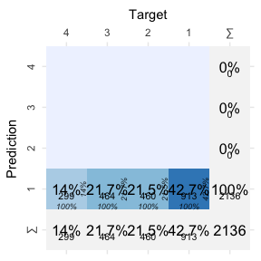

```
#> [1] "accuracy"
#> [1] 0.4274345
#> [1] "precision"
#>         1
#> 0.4274345
#> [1] "recall"
#>        1        2        3        4
#> 1.000000 1.984783 1.967672 3.053512
#> [1] "F1 score"
#>         1         2         3         4
#> 0.5988849 0.7033898 0.7023077 0.7498973
```

# Ordinal Logistic Regression Model

Ordinal logistic regression is used to determine the relationship between a set of predictors and an ordered factor dependent variable (such as rating). In ordinal logistic regression, the levels within the dependent variable is assumed to have a ordinal features, such as rating 1 is one-step higher than rating 2, and it’s 2-step higher than rating 3. In contrast to multinomial regression, where there is NO ordinal structure for the levels within the dependent variable (such as y %in% c(“apple”,“orange”,“pear”)).

$$logit[P(Y \leq j)] = \alpha_j - \beta x, j = 1 ... J-1$$

$$Thus,P(Y \leq j) = \frac{exp(\alpha_j - \beta x)}{1+exp(\alpha_j - \beta x)}, j = 1 ... J-1$$
where $\alpha_j$ is the threshold coefficient corresponding to the particular rating, $\beta$ is the variable coefficient corresponding to a change in a predictor variable, and $x$ is the value of the predictor variable.

```
#> Call:
#> polr(formula = answer ~ duration + offer + outcome + price +
#>     rtb + social_proof, data = train_model_data, Hess = TRUE)
#>
#> Coefficients:
#>                                                           Value Std. Error
#> duration6 months                                       0.023278    0.04796
#> duration12 months                                      0.019913    0.04906
#> offerhelp you lead a better life                       0.047119    0.06225
#> offerhelp you sleep without more pills                 0.044981    0.06277
#> offerimprove your health for the long-run              0.056665    0.06215
#> offerimprove your sleep sustainably                    0.027999    0.06304
#> outcomechanging your sleep mindset                     0.004504    0.04826
#> outcomeempowering you to take back your sleep habits  -0.104553    0.04871
#> price$30/month                                        -0.374938    0.04826
#> price$40/month                                        -0.529550    0.04860
#> rtbcognitive behavioral therapy                        0.001435    0.06768
#> rtbdaily text messages from a coach                   -0.162213    0.06874
#> rtbpersonalized, human coaching                       -0.013132    0.06809
#> rtbthe support of a community of people just like you -0.080482    0.06875
#> rtbunique daily games, challenges and exercises       -0.137294    0.06879
#> social_proofleading researchers                        0.111960    0.05615
#> social_proofprofessional athletes                      0.025999    0.05603
#> social_proofscientific evidence                        0.107254    0.05544
#>                                                         t value
#> duration6 months                                        0.48533
#> duration12 months                                       0.40589
#> offerhelp you lead a better life                        0.75692
#> offerhelp you sleep without more pills                  0.71657
#> offerimprove your health for the long-run               0.91178
#> offerimprove your sleep sustainably                     0.44412
#> outcomechanging your sleep mindset                      0.09334
#> outcomeempowering you to take back your sleep habits   -2.14639
#> price$30/month                                         -7.76852
#> price$40/month                                        -10.89632
#> rtbcognitive behavioral therapy                         0.02121
#> rtbdaily text messages from a coach                    -2.35980
#> rtbpersonalized, human coaching                        -0.19287
#> rtbthe support of a community of people just like you  -1.17060
#> rtbunique daily games, challenges and exercises        -1.99598
#> social_proofleading researchers                         1.99389
#> social_proofprofessional athletes                       0.46399
#> social_proofscientific evidence                         1.93448
#>
#> Intercepts:
#>     Value    Std. Error t value
#> 1|2  -0.5862   0.0858    -6.8358
#> 2|3   0.3441   0.0856     4.0216
#> 3|4   1.4876   0.0875    16.9952
#>
#> Residual Deviance: 22183.68
#> AIC: 22225.68
#> [1] 0.4274345
```

**Interpretation of the model results:**

- Duration:
  - Compared to duration = 3 months, 6-month duration will cause the likelihood of a rating 4 vs. a rating 1-3 change by 0.0232779 on the log odds scale, and same amount of changes will happen to the likelihood of a rating 3 vs. a rating 1-2 & the likelihood of a rating 2 vs. a rating 1
  - Compared to duration = 3 months, 12-month duration will cause the likelihood of a rating 4 vs. a rating 1-3 change by 0.019913 on the log odds scale, and same amount of changes will happen to the likelihood of a rating 3 vs. a rating 1-2 & the likelihood of a rating 2 vs. a rating 1
- Price:
  - Compared to price = $20/month, $30/month will cause the likelihood of a rating 4 vs. a rating 1-3 change by -0.3749376 on the log odds scale, and same amount of changes will happen to the likelihood of a rating 3 vs. a rating 1-2 & the likelihood of a rating 2 vs. a rating 1
  - Compared to price = $20/month, $40/month will cause the likelihood of a rating 4 vs. a rating 1-3 change by -0.5295504 on the log odds scale, and same amount of changes will happen to the likelihood of a rating 3 vs. a rating 1-2 & the likelihood of a rating 2 vs. a rating 1

Similar interpretation can be generated for the remaining of the predictors. The baseline level for each categorical variables are the following:

```r
data.frame(
  Predictors = c("duration","offer","outcome","price","rtb","social_proof"),
  Baseline_Level = c("3 months","give you the energy to unlock your fullest potential",
                     "breaking bad habits and creating new routines","$20/month",
                     "a program created just for you","a method that has helped thousands")
)
```

```
#>     Predictors                                       Baseline_Level
#> 1     duration                                             3 months
#> 2        offer give you the energy to unlock your fullest potential
#> 3      outcome        breaking bad habits and creating new routines
#> 4        price                                            $20/month
#> 5          rtb                       a program created just for you
#> 6 social_proof                   a method that has helped thousands
```

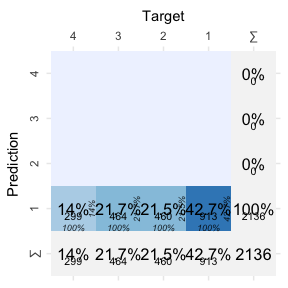

```r
conf_mat <- confusion_matrix(targets = olr_predictions$actual,
                             predictions = olr_predictions$prediction)
plot_confusion_matrix(conf_mat$`Confusion Matrix`[[1]],
                      add_sums = TRUE)
```

```r
print("Accuracy")
```

```
#> [1] "Accuracy"
```

```r
GradientMetrics::model_performance_metrics(predictions = olr_predictions$prediction,
                          targets = olr_predictions$actual)[[1]] # accuracy:0.4274345
```

```
#> [1] 0.4274345
```

```r
print("Precision")
```

```
#> [1] "Precision"
```

```r
GradientMetrics::model_performance_metrics(predictions = olr_predictions$prediction,
                          targets = olr_predictions$actual)[[2]] # precision
```

```
#>         1
#> 0.4274345
```

```r
print("Recall")
```

```
#> [1] "Recall"
```

```r
GradientMetrics::model_performance_metrics(predictions = olr_predictions$prediction,
                          targets = olr_predictions$actual)[[3]] # recall
```

```
#>        1        2        3        4
#> 1.000000 1.984783 1.967672 3.053512
```

```r
print("F1 Score")
```

```
#> [1] "F1 Score"
```

```r
GradientMetrics::model_performance_metrics(predictions = olr_predictions$prediction,
                          targets = olr_predictions$actual)[[4]] # f1
```

```
#>         1         2         3         4
#> 0.5988849 0.7033898 0.7023077 0.7498973
```

[output not shown]

[interactive chart not shown]

# Ordinal Mixed Effect Model

Given the fact that each participants were randomly given 12 permutations of the message attributes, each participants has 12 observations, each corresponding to his/her rating for download likelihood. The previous 2 models did NOT account for the random effect within the data. Ordinal mixed effect model (specifically, cumulative link mixed model) can address this issue.

The assumption of independence of observations applies to all regression models. When multiple measurements are taken on the same individual, this assumption is violated. In order to account for dependent observations, a random effect can be added to the previous model. Cumulative link mixed models have the following general form:

$$logit[P(Y_i \leq j)] = \alpha_j - (Z_{t[i]}u_t + x_i\beta) \\
\text{where } u_t \sim N(0,\sigma_u^2)$$

$u_t$ represents the vector of coefficients corresponding to the group-level predictors $Z_{t[i]}$ for observation $i$ in cluster/participant $t$. This model has the added assumption that the random effects are Normally distributed and centered at zero. The random effect induces the correlation expected between observations in the same cluster/participants.

Since the experiment data contains 892 participants, when I used response_id as random effect variable, the model could not converge (convergence is needed in order to produce the Hessian matrix & corresponding standard error for each estimated coefficient).

Therefore, I used a clustering technique to first group participants into different clusters using social-demographic features from Survey Data. And assign random effect variable to this cluster variable in the ordinal mixed effect model.

```r
library(poLCA)
```

[figure not shown]

```r
survey_data3 = survey_data
survey_data3[is.na(survey_data3)] <- 0

# f1 = as.formula(cbind(d_urban,s_gender,s_race,d_education,s_hhincome,s_problem)~1)
f2 = as.formula(cbind(source_1,source_4,source_5,source_6,source_7,source_8,source_9,source_10,source_11,source_12,source_13,source_14,source_15,source_16,source_17)~1)

source_df = survey_data3 %>% dplyr::select(contains("source"))
source_df[(source_df==1)] <- 2
source_df[(source_df==0)] <- 1
LCA1 = poLCA(f2,data = source_df,nclass=3,nrep = 10,verbose = FALSE)
plot(LCA1)
```

```r
survey_data3$cluster_source = LCA1$predclass
train_model_data2 = train_model_data %>%
  left_join(survey_data3 %>%
  dplyr::select(response_id,cluster_source),on = c("response_id"="response_id")) %>%
  mutate(duration = factor(duration,levels = c("3 months","6 months","12 months")),
    price = factor(price,levels = c("$20/month","$30/month","$40/month"))
  )
test_model_data2 = test_model_data %>%
  left_join(survey_data3 %>%
  dplyr::select(response_id,cluster_source),on = c("response_id"="response_id")) %>%
  mutate(duration = factor(duration,levels = c("3 months","6 months","12 months")),
    price = factor(price,levels = c("$20/month","$30/month","$40/month"))
  )
# fitLCA <- function(k){
#   poLCA(cbind(m1_philosophy_1, m1_philosophy_2, m1_philosophy_3,
#                    m1_philosophy_4, m1_philosophy_5, m1_philosophy_6,
#                    m1_philosophy_7, m1_philosophy_8, m1_philosophy_9)~1,
#         data=survey_data, nclass = k, nrep=10)
# }
# # Apply the function to successively increasingly classes K=1,2,3....,6
# MK <- lapply(1:6, fitLCA)
# # Possible to look at AIC, BIC, etc.
# sapply(MK, `[[`, "aic")
# sapply(MK, `[[`, "bic")
```

As we can see from the visualization above, for the 3 clusters the model defined:

- Given participant is in $1^{st}$ cluster (left column), the probabilities of him/her having BOTH physical (source 5: a chronic condition (e.g. cancer, diabetes, cardiovascular disease etc.)) and psychological sources (Source 8: Stress from current events (e.g. pandemic, politics)) of sleep issues are quite high.
- Given a participant is in $2^{nd}$ cluster, he/she is characterized by high probabilities of reporting Other sources of sleep issues (a.k.a. not listed in the survey)
- Given a participant is in $3^{rd}$ cluster, he/she is more likely to have psychological sources of sleep issues (source 7,8,9 which are mostly chronic anxiety, depression from both personal life and current events)

The following cumulative link mixed effect uses all 6 message attributes (duration, offer, outcome etc.) as fixed effect variable and uses the source cluster as random effect variable.

```r
library(ordinal)
model7 = clmm(answer~duration+offer+outcome+price+rtb+social_proof+(1|cluster_source),
               link='logit',
               data= train_model_data2,
               Hess=TRUE, nAGQ=1)
summary(model7) # AIC = 21757.87
```

```
#> Cumulative Link Mixed Model fitted with the Laplace approximation
#>
#> formula: answer ~ duration + offer + outcome + price + rtb + social_proof +
#>     (1 | cluster_source)
#> data:    train_model_data2
#>
#>  link  threshold nobs logLik    AIC      niter       max.grad cond.H
#>  logit flexible  8568 -10856.93 21757.87 4848(19396) 1.25e-02 4.2e+03
#>
#> Random effects:
#>  Groups         Name        Variance Std.Dev.
#>  cluster_source (Intercept) 0.7275   0.8529
#> Number of groups:  cluster_source 3
#>
#> Coefficients:
#>                                                         Estimate Std. Error
#> duration6 months                                       0.0230656  0.0485385
#> duration12 months                                      0.0382071  0.0497072
#> offerhelp you lead a better life                       0.0332564  0.0630062
#> offerhelp you sleep without more pills                 0.0242581  0.0635391
#> offerimprove your health for the long-run              0.0544075  0.0629654
#> offerimprove your sleep sustainably                    0.0357280  0.0638645
#> outcomechanging your sleep mindset                    -0.0007612  0.0488385
#> outcomeempowering you to take back your sleep habits  -0.1028530  0.0493232
#> price$30/month                                        -0.3986291  0.0488636
#> price$40/month                                        -0.5516253  0.0492288
#> rtbcognitive behavioral therapy                        0.0266370  0.0684589
#> rtbdaily text messages from a coach                   -0.1434359  0.0695590
#> rtbpersonalized, human coaching                       -0.0010858  0.0689022
#> rtbthe support of a community of people just like you -0.0754574  0.0696089
#> rtbunique daily games, challenges and exercises       -0.1358244  0.0696522
#> social_proofleading researchers                        0.1148348  0.0568185
#> social_proofprofessional athletes                      0.0468074  0.0567550
#> social_proofscientific evidence                        0.1166636  0.0561378
#>                                                       z value Pr(>|z|)
#> duration6 months                                        0.475   0.6346
#> duration12 months                                       0.769   0.4421
#> offerhelp you lead a better life                        0.528   0.5976
#> offerhelp you sleep without more pills                  0.382   0.7026
#> offerimprove your health for the long-run               0.864   0.3875
#> offerimprove your sleep sustainably                     0.559   0.5759
#> outcomechanging your sleep mindset                     -0.016   0.9876
#> outcomeempowering you to take back your sleep habits   -2.085   0.0370 *
#> price$30/month                                         -8.158 3.41e-16 ***
#> price$40/month                                        -11.205  < 2e-16 ***
#> rtbcognitive behavioral therapy                         0.389   0.6972
#> rtbdaily text messages from a coach                    -2.062   0.0392 *
#> rtbpersonalized, human coaching                        -0.016   0.9874
#> rtbthe support of a community of people just like you  -1.084   0.2784
#> rtbunique daily games, challenges and exercises        -1.950   0.0512 .
#> social_proofleading researchers                         2.021   0.0433 *
#> social_proofprofessional athletes                       0.825   0.4095
#> social_proofscientific evidence                         2.078   0.0377 *
#> ---
#> Signif. codes:  0 '***' 0.001 '**' 0.01 '*' 0.05 '.' 0.1 ' ' 1
#>
#> Threshold coefficients:
#>     Estimate Std. Error z value
#> 1|2  -0.1060     0.4998  -0.212
#> 2|3   0.8614     0.4999   1.723
#> 3|4   2.0345     0.5002   4.067
```

```r
ctable = coef(summary(model7))
ctable
```

```
#>                                                            Estimate Std. Error
#> 1|2                                                   -0.1060170785 0.49980802
#> 2|3                                                    0.8613802996 0.49985243
#> 3|4                                                    2.0345301858 0.50024887
#> duration6 months                                       0.0230656331 0.04853845
#> duration12 months                                      0.0382070694 0.04970722
#> offerhelp you lead a better life                       0.0332564206 0.06300619
#> offerhelp you sleep without more pills                 0.0242581263 0.06353914
#> offerimprove your health for the long-run              0.0544075249 0.06296541
#> offerimprove your sleep sustainably                    0.0357280046 0.06386451
#> outcomechanging your sleep mindset                    -0.0007612424 0.04883847
#> outcomeempowering you to take back your sleep habits  -0.1028530140 0.04932325
#> price$30/month                                        -0.3986290921 0.04886362
#> price$40/month                                        -0.5516253044 0.04922883
#> rtbcognitive behavioral therapy                        0.0266370253 0.06845886
#> rtbdaily text messages from a coach                   -0.1434359191 0.06955903
#> rtbpersonalized, human coaching                       -0.0010858090 0.06890222
#> rtbthe support of a community of people just like you -0.0754573604 0.06960888
#> rtbunique daily games, challenges and exercises       -0.1358244133 0.06965223
#> social_proofleading researchers                        0.1148347938 0.05681851
#> social_proofprofessional athletes                      0.0468073640 0.05675495
#> social_proofscientific evidence                        0.1166636234 0.05613779
#>                                                            z value     Pr(>|z|)
#> 1|2                                                    -0.21211560 8.320168e-01
#> 2|3                                                     1.72326922 8.483985e-02
#> 3|4                                                     4.06703601 4.761489e-05
#> duration6 months                                        0.47520332 6.346421e-01
#> duration12 months                                       0.76864220 4.421057e-01
#> offerhelp you lead a better life                        0.52782785 5.976188e-01
#> offerhelp you sleep without more pills                  0.38178242 7.026228e-01
#> offerimprove your health for the long-run               0.86408587 3.875407e-01
#> offerimprove your sleep sustainably                     0.55943444 5.758653e-01
#> outcomechanging your sleep mindset                     -0.01558694 9.875639e-01
#> outcomeempowering you to take back your sleep habits   -2.08528478 3.704346e-02
#> price$30/month                                         -8.15799312 3.406369e-16
#> price$40/month                                        -11.20533038 3.839187e-29
#> rtbcognitive behavioral therapy                         0.38909535 6.972056e-01
#> rtbdaily text messages from a coach                    -2.06207472 3.920062e-02
#> rtbpersonalized, human coaching                        -0.01575869 9.874269e-01
#> rtbthe support of a community of people just like you  -1.08401912 2.783563e-01
#> rtbunique daily games, challenges and exercises        -1.95003696 5.117171e-02
#> social_proofleading researchers                         2.02108057 4.327143e-02
#> social_proofprofessional athletes                       0.82472740 4.095264e-01
#> social_proofscientific evidence                         2.07816545 3.769412e-02
```

**Interpretation of the model results:**

```r
data.frame(
  Predictors = c("duration","offer","outcome","price","rtb","social_proof"),
  Baseline_Level = c("3 months","give you the energy to unlock your fullest potential",
                     "breaking bad habits and creating new routines","$20/month",
                     "a program created just for you","a method that has helped thousands")
)
```

```
#>     Predictors                                       Baseline_Level
#> 1     duration                                             3 months
#> 2        offer give you the energy to unlock your fullest potential
#> 3      outcome        breaking bad habits and creating new routines
#> 4        price                                            $20/month
#> 5          rtb                       a program created just for you
#> 6 social_proof                   a method that has helped thousands
```

**Overall, the model performance of all 3 models are summarized below: the ordinal mixed effect model using source cluster as random effect variable yields the smallest number of in-sample AIC.**

```r
data.frame(
  model = c("Multinomial Logistic Regression", "Ordinal Logistic Regression", "Ordinal Mixed Effect Model"),
  AIC = c(round(summary(mlr)$AIC,2),
          round(olr$deviance,2),
          summary(model7)$info["AIC"] %>% pull())

)
```

[output not shown]

## Future Improvement

Ideally, a K-folder cross validation should be use to train, validate and test the model, where out-of-sample performance metrics can be calculated to evaluate the accuracy of the predictions.

Group Lasso

## Reference

https://stats.idre.ucla.edu/r/dae/multinomial-logistic-regression/ https://data.princeton.edu/wws509/notes/c6.pdf https://math.montana.edu/grad_students/writing-projects/2012/12schmidt.pdf